# Exercise R1.2: First Reproducible R Script

STAT 540 — Week 1

Author

Sokhna Amar

Published

August 30, 2026

## Overview

In this exercise, you will create a reproducible R analysis using a built-in dataset, practice basic data inspection, and commit your work to GitHub.

## Task 1: Load and Inspect mtcars

The `mtcars` dataset is one of R’s classic built-in datasets. It contains data from the 1974 *Motor Trend* magazine about 32 automobiles.

```r
# Load the dataset (built-in, no package needed)
data(mtcars)

# View the first 5 rows
head(mtcars, 5)
```

```
                   mpg cyl disp  hp drat    wt  qsec vs am gear carb
Mazda RX4         21.0   6  160 110 3.90 2.620 16.46  0  1    4    4
Mazda RX4 Wag     21.0   6  160 110 3.90 2.875 17.02  0  1    4    4
Datsun 710        22.8   4  108  93 3.85 2.320 18.61  1  1    4    1
Hornet 4 Drive    21.4   6  258 110 3.08 3.215 19.44  1  0    3    1
Hornet Sportabout 18.7   8  360 175 3.15 3.440 17.02  0  0    3    2
```

```r
# View the last 3 rows
tail(mtcars, 3)
```

```
               mpg cyl disp  hp drat   wt qsec vs am gear carb
Ferrari Dino  19.7   6  145 175 3.62 2.77 15.5  0  1    5    6
Maserati Bora 15.0   8  301 335 3.54 3.57 14.6  0  1    5    8
Volvo 142E    21.4   4  121 109 4.11 2.78 18.6  1  1    4    2
```

```r
# What are the dimensions?
dim(mtcars)
```

```
[1] 32 11
```

```r
# What are the column names?
names(mtcars)
```

```
 [1] "mpg"  "cyl"  "disp" "hp"   "drat" "wt"   "qsec" "vs"   "am"   "gear"
[11] "carb"
```

```r
# Structure of the dataset
str(mtcars)
```

```
'data.frame':   32 obs. of  11 variables:
 $ mpg : num  21 21 22.8 21.4 18.7 18.1 14.3 24.4 22.8 19.2 ...
 $ cyl : num  6 6 4 6 8 6 8 4 4 6 ...
 $ disp: num  160 160 108 258 360 ...
 $ hp  : num  110 110 93 110 175 105 245 62 95 123 ...
 $ drat: num  3.9 3.9 3.85 3.08 3.15 2.76 3.21 3.69 3.92 3.92 ...
 $ wt  : num  2.62 2.88 2.32 3.21 3.44 ...
 $ qsec: num  16.5 17 18.6 19.4 17 ...
 $ vs  : num  0 0 1 1 0 1 0 1 1 1 ...
 $ am  : num  1 1 1 0 0 0 0 0 0 0 ...
 $ gear: num  4 4 4 3 3 3 3 4 4 4 ...
 $ carb: num  4 4 1 1 2 1 4 2 2 4 ...
```

**Your turn:** In your own words, describe what each row represents and name three variables you find interesting.

> Each row represents the individual car models in the mtcars dataset, with specific details according to the variables. I find the ‘mpg’, ‘wt’, and ‘hp’ variables to be quite interesting, as these are the details I pay attention to the most when looking into cars.

## Task 2: Compute Summary Statistics

```r
# Mean miles per gallon
mean_mpg <- mean(mtcars$mpg)
cat("Mean MPG:", mean_mpg, "\n")
```

```
Mean MPG: 20.09062
```

```r
# Median horsepower
median_hp <- median(mtcars$hp)
cat("Median HP:", median_hp, "\n")
```

```
Median HP: 123
```

```r
# Standard deviation of weight
sd_wt <- sd(mtcars$wt)
cat("SD of Weight:", sd_wt, "\n")
```

```
SD of Weight: 0.9784574
```

```r
# Range of quarter-mile time
range_qsec <- range(mtcars$qsec)
cat("Quarter-mile time range:", range_qsec[1], "to", range_qsec[2], "\n")
```

```
Quarter-mile time range: 14.5 to 22.9
```

**Your turn:** Compute the following and report the values:

1. The mean weight (`wt`) of all cars: ___
2. The maximum horsepower (`hp`): ___
3. The number of cars with 4 cylinders: ___

```r
# Your code for the three computations above:
# 1.
mean(mtcars$wt)
```

```
[1] 3.21725
```

```r
# 2.
max(mtcars$hp)
```

```
[1] 335
```

```r
# 3.
sum(mtcars$cyl == 4)
```

```
[1] 11
```

The mean weight of the cars is 3217.25 pounds. The maximum horsepower is 335, and there are 11 cars with 4 cylinders.

## Task 3: Grouped Summaries

Compute the mean MPG for each number of cylinders:

```r
# Base R approach
tapply(mtcars$mpg, mtcars$cyl, mean)
```

```
       4        6        8
26.66364 19.74286 15.10000
```

```r
# Tidyverse approach
library(dplyr)
mtcars |>
  group_by(cyl) |>
  summarize(
    mean_mpg = mean(mpg),
    mean_hp = mean(hp),
    count = n()
  )
```

```
# A tibble: 3 × 4
    cyl mean_mpg mean_hp count
  <dbl>    <dbl>   <dbl> <int>
1     4     26.7    82.6    11
2     6     19.7   122.      7
3     8     15.1   209.     14
```

**Your turn:** Write a sentence interpreting the relationship between number of cylinders and fuel efficiency:

> There is a negative correlation between the number of cylinders and fuel efficiency; the more cylinders there are, the less mpg the cars have.

## Task 4: Your First Visualization

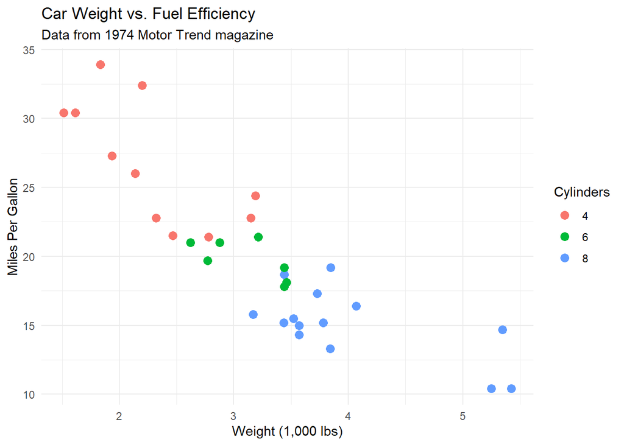

```r
library(ggplot2)

# Scatterplot of weight vs. MPG, colored by cylinder count
ggplot(mtcars, aes(x = wt, y = mpg, color = factor(cyl))) +
  geom_point(size = 3) +
  labs(
    title = "Car Weight vs. Fuel Efficiency",
    subtitle = "Data from 1974 Motor Trend magazine",
    x = "Weight (1,000 lbs)",
    y = "Miles Per Gallon",
    color = "Cylinders"
  ) +
  theme_minimal()
```

**Your turn:** Modify the plot above to also include a smooth trend line for each cylinder group. Hint: add `geom_smooth(method = "lm", se = FALSE)` to the plot.

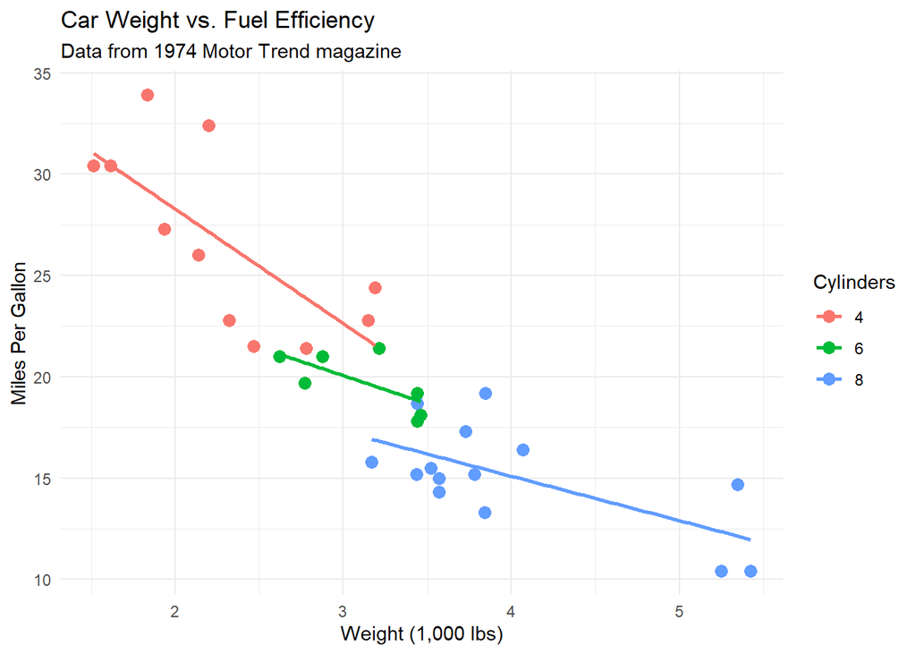

```r
# Your modified plot code here:
ggplot(mtcars, aes(x = wt, y = mpg, color = factor(cyl))) +
  geom_point(size = 3) +
  labs(
    title = "Car Weight vs. Fuel Efficiency",
    subtitle = "Data from 1974 Motor Trend magazine",
    x = "Weight (1,000 lbs)",
    y = "Miles Per Gallon",
    color = "Cylinders"
  ) +
  theme_minimal() +
  geom_smooth(method = "lm", se = FALSE)
```

## Task 5: Write a Data Summary

In 3–5 sentences, summarize what you learned about the mtcars dataset. Include at least one specific number from your analysis and one observation from your visualization.

> The mt cars dataset contains information about fuel consumption, horsepower, and various design characteristics from various cars from 1973-74. What I found particularly interesting was the correlation between the number of cylinders, which ranged from 4-8, and the vehicle’s average fuel efficiency, which ranged from a mean of about 15 mpg to 26 mpg. To be more specific, the lower the amount of cylinders, the farther a car could travel on a gallon of gas. Visualizing this on a scatter plot also showed how weight correlated with the number of cylinders as well.

## Task 6: Commit to GitHub

1. Save this completed `.qmd` file
2. Render it to HTML
3. In the terminal, commit and push:

```bash
git add week01/exercises/R1.2-first-script.qmd
git add week01/exercises/R1.2-first-script.html
git commit -m "Complete Exercise R1.2: mtcars analysis"
git push origin main
```

## Submission Checklist

- All code chunks run without errors
- All “Your turn” sections are completed
- Data summary paragraph is written
- Modified visualization includes trend lines
- Both `.qmd` and `.html` files are committed to GitHub
- Commit message is descriptive